# template-sol

### Template for PC Session

Let's solve question number 2 in Problem Set 0

**2. A simulation exercise:**

Suppose evolution of variable $x$ over time is defined with the following formula:

$$ x(t+1) = mx(t)^{\alpha}+ nx(t), $$

where $m=0.2$, $\alpha=0.5$, and $n=0.9$, meaning the value of $x$ at time $t+1$ is equal to 0.2 times the value of $x$ at time $t$ to the power 0.5 plus 0.9 times the value of $x$ at time $t$. Suppose $x(0)=1$, the value of $x$ at time $t=0$ is equal to 1.

Simulate $x$ for 100 periods starting from time $t=0$.

**Hint**: You know $x(0)$. Using the above formula and the value of $x(0)$, you can find $x(1)$. Then using the above formula and the value of $x(1)$, you can calculate $x(2)$. You can repeat this exercise until you reach $x(100)$.

*Again, I don't want you to write the same formula 100 times. It will take so much time, which is not my goal. If you are using excel, write the formula once in such a way that you can drag the cell down and simulate $x$ for as many periods as you wish.*

Let's solve the question step by step

```python
# Define variables m, alpha, and n in this cell
```

```python
# Two options:

# 1st one
m = 0.2
alpha = 0.5
n = 0.9

# second one
m, alpha, n = 0.2,0.5,0.9
```

```python
# Now, we will write a for loop.
# Before writing the loop required in the question, let's begin with an easier for loop.
# Write for loop that prints x^2 for each value of x between 0 and 100.
```

```python
T = 100
for x in range(T):
    print(x**2)
```

```
0
1
4
9
16
25
36
49
64
81
100
121
144
169
196
225
256
289
324
361
400
441
484
529
576
625
676
729
784
841
900
961
1024
1089
1156
1225
1296
1369
1444
1521
```

[output cut: 45 more lines]

```
7225
7396
7569
7744
7921
8100
8281
8464
8649
8836
9025
9216
9409
9604
9801
```

```python
## Let's write the loop required by the question
```

```python
x = []
x.append(1)
for t in range(T):
    x.append(m*x[t]**alpha+n*x[t])
```

```python
# Now, we will re-do the question with a function
# Write a python function of m times (x(t) to the power alpha) + n times x(t)
```

```python
def f(x):
    y = m*x**alpha+n*x
    return y
```

```python
f(2),f(4),f(6)
```

```
(2.082842712474619, 4.0, 5.889897948556636)
```

```python
# Re-write the for loop with the function you defined above
```

```python
x = []
x.append(1)
for t in range(T):
    x.append(f(x[t]))
```

```python
# Plot x(t) series
```

```python
import matplotlib.pyplot as plt
```

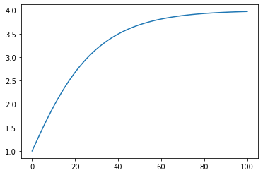

```python
plt.plot(x)
```

```python
# Let's do the exercise from Quant Econ
```

### Exercise 1

Your first task is to simulate and plot the correlated time series

$$ x_{t+1} = \alpha \, x_t + \epsilon_{t+1} \quad \text{where} \quad x_0 = 0 \quad \text{and} \quad t = 0,\ldots,T $$

In your solution, restrict your import statements to

```python
import numpy as np
import matplotlib.pyplot as plt
```

Set $ T=200 $ and $ \alpha = 0.9 $.

```python
T,alpha = 200,0.9
```

```python
epsilon = np.random.rand(T)
```

```python
def simul(alpha):
    x = [0]
    for t in range(T):
        x.append(alpha*x[t]+epsilon[t])
    return x
```

```python
simul(alpha)
```

```
[0,
 0.6101535757889703,
 1.1943824191356875,
 1.8109902309105659,
 2.053133099875235,
 2.421786404610579,
 2.443572329785316,
 2.5652503690229533,
 3.0503892182535313,
 3.052099525231196,
 3.1770576473067385,
 2.863637514563094,
 2.7334029125393684,
 3.419218371901583,
 3.7562622454518,
 3.437830297109816,
 3.381074210158649,
 3.9362463242651606,
 4.481535687915654,
 4.431737154687093,
 4.264305410001347,
 4.4495315043718175,
 4.7309797794550175,
 4.816529594039484,
 4.662306703200432,
 4.619608339688949,
 4.652117250170954,
 4.850317735670684,
 4.871685636187506,
 4.907530682552828,
 4.426821288382714,
 4.035734727735369,
 4.2276778505073,
 4.501285472878714,
 4.702640971111381,
 4.803034461611934,
 4.327391098570201,
 4.086676464093538,
 3.7652132760869215,
 4.11754056071787,
```

[output cut: 146 more lines]

```
 5.307102537317123,
 4.956018668448228,
 5.306269669738175,
 4.924899561716384,
 4.491891093023892,
 4.520877278494905,
 4.4392902877772595,
 4.166351779619007,
 3.934330210337427,
 3.969540636638472,
 3.9097865645439605,
 4.143762320784968,
 4.410017599585076,
 4.623295781440478,
 4.99258659595731]
```

### Exercise 2

Starting with your solution to exercise 1, plot three simulated time series, one for each of the cases $ \alpha=0 $, $ \alpha=0.8 $ and $ \alpha=0.98 $.

Use a `for` loop to step through the $ \alpha $ values.

If you can, add a legend, to help distinguish between the three time series.

Hints:

- If you call the `plot()` function multiple times before calling `show()`, all of the lines you produce will end up on the same figure.
- For the legend, noted that the expression `'foo' + str(42)` evaluates to `'foo42'`.

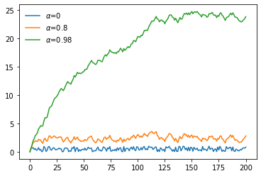

```python
for alpha in [0,0.8,0.98]:
    plt.plot(simul(alpha),label=r'$\alpha$'+f'={alpha}')
plt.legend(loc='best',frameon=False)
```